# Modul 00: Pengantar R dan RStudio untuk Pemula

# 1 Pengenalan R dan RStudio

Selamat datang di seri **Panduan Analisis Statistik & Komputasi R**. Sebelum mempelajari perancangan percobaan (RAL, RAK, Faktorial, *Split-Plot*, *Strip-Plot*), analisis korelasi, dan pemodelan regresi, modul pembuka ini dirancang khusus bagi Anda yang **belum pernah menggunakan R sama sekali** agar dapat mengoperasikan R dan RStudio secara mandiri dari nol.

## 1.1 Apa Itu R?

**Konsep Dasar — Bahasa Pemrograman R:**

**R** adalah bahasa pemrograman sekaligus lingkungan perangkat lunak komputasi statistik dan grafik ilmiah yang dikembangkan pertama kali oleh **Ross Ihaka** dan **Robert Gentleman** di Auckland, Selandia Baru (1993), dan kini dikelola oleh *R Core Team*. Di bidang pertanian, biologi, kehutanan, peternakan, dan perikanan, R telah menjadi standar emas analisis data penelitian internasional.

Empat keunggulan utama R dibandingkan perangkat lunak statistik berbayar berbasis menu adalah:

1. **Gratis dan Terbuka (*Open-Source*)**: Dapat diunduh dan digunakan secara bebas tanpa biaya lisensi di Windows, macOS, maupun Linux.
2. **Ekosistem Ribuan Paket Spesifik di CRAN**: Tersedia lebih dari 20.000 paket (*packages*) di *Comprehensive R Archive Network* (CRAN), termasuk paket khusus penelitian pertanian seperti `agricolae` (rancangan percobaan & uji lanjut), `emmeans` (uji pengaruh sederhana interaksi), `multcomp` (uji Dunnett & perbandingan berganda), `car` (diagnostik multikolinieritas), hingga `pls` (regresi komponen utama).
3. **Visualisasi Berkualitas Publikasi Ilmiah**: Mampu menghasilkan grafik eksplorasi, kurva respons polinomial, plot interaksi, hingga grafik diagnostik sisaan beresolusi tinggi.
4. **Penelitian yang Dapat Direproduksi (*Reproducible Research*)**: Seluruh tahapan pembersihan data, analisis ANOVA/regresi, hingga pembuatan laporan HTML/PDF/Word terekam rapi di dalam *script* `.R` atau `.Rmd`, sehingga analisis dapat diulang kapan saja tanpa takut lupa urutan klik menu.

## 1.2 Apa Itu RStudio & Panduan Instalasi Berurutan

Jika **R** diibaratkan sebagai **“mesin mobil”** yang bekerja menghitung rumus-rumus statistika di balik layar, maka **RStudio** adalah **“kabin kemudi (*dashboard*)”** atau *Integrated Development Environment* (IDE) yang menyediakan tombol, layar editor kode, jendela grafik, dan tabel data yang nyaman digunakan.

**Urutan Instalasi Wajib (Jangan Terbalik!):**

1. **Langkah 1 — Instal R (Mesin Utama) terlebih dahulu**:
   - Kunjungi situs resmi CRAN di https://cran.r-project.org/.
   - Pilih sistem operasi Anda (*Download R for Windows* / *macOS* / *Linux*), klik **base**, lalu unduh penginstal versi terbaru (misalnya `R-4.x.x-win.exe`) dan jalankan dengan pengaturan *default*.
2. **Langkah 2 — Instal RStudio Desktop (Antarmuka IDE)**:
   - Kunjungi situs resmi Posit di https://posit.co/download/rstudio-desktop/.
   - Unduh pemasang **RStudio Desktop (Free)** sesuai sistem operasi Anda dan jalankan hingga selesai.
3. **Langkah 3 — Buka RStudio**:
   - Untuk bekerja sehari-hari, Anda cukup membuka aplikasi **RStudio** (R akan otomatis terpanggil di dalamnya).

# 2 Mengenal Lingkungan 4 Panel RStudio

Saat Anda membuka RStudio dan membuat lembar skrip baru melalui menu **File > New File > R Script** (atau menekan `Ctrl + Shift + N`), layar RStudio akan terbagi menjadi **4 panel utama**:

| Panel RStudio | Posisi Layar | Fungsi Utama dalam Komputasi Statistik |
| --- | --- | --- |
| **1. Source (Script Editor)** | **Kiri Atas** | Tempat menulis, mengedit, dan menyimpan barisan kode dalam file `.R` atau `.Rmd`. Kode tidak langsung hilang setelah dijalankan. |
| **2. Console** | **Kiri Bawah** | Tempat “mesin R” mengeksekusi perintah secara langsung dan mencetak hasil perhitungan angka, tabel ANOVA, atau pesan *error*. |
| **3. Environment & History** | **Kanan Atas** | Memantau seluruh objek data (*data frame*, vektor, matriks, objek model `aov`/`lm`) yang sedang aktif tersimpan di memori komputer. |
| **4. Files, Plots, Packages, Help** | **Kanan Bawah** | Menjelajahi folder kerja (*Files*), menampilkan grafik (*Plots*), mengelola paket (*Packages*), dan membaca panduan rumus/argumen fungsi (*Help*). |

**Tips Eksekusi Kode Cepat di RStudio:**

- Letakkan kursor pada baris kode di panel **Source** (atau blok beberapa baris sekaligus), lalu tekan **`Ctrl + Enter`** (Windows/Linux) atau **`Cmd + Return`** (macOS) untuk mengirim dan menjalankan baris tersebut ke **Console**.
- Tanda **`>`** pada *Console* berarti R siap menerima perintah baru.
- Tanda **`+`** pada awal baris *Console* berarti perintah sebelumnya **belum lengkap** (misalnya lupa menutup tanda kurung `)` atau tanda kutip `"`). Tekan tombol `Esc` untuk membatalkannya.
- Tanda pagar **`#`** digunakan untuk menulis **komentar/catatan penjelasan**; seluruh teks di sebelah kanan `#` pada baris tersebut akan diabaikan oleh R.

# 3 Fungsi, Paket, dan Direktori Kerja

## 3.1 Konsep Dasar & Kapan Digunakan

Di dalam R, hampir seluruh pekerjaan statistik dilakukan dengan memanggil **fungsi (*function*)** yang memiliki pola penulisan baku:

$$\text{nama\_fungsi}(\text{argumen}_1, \text{argumen}_2, \dots)$$

Sebagian fungsi dasar seperti `mean()`, `sd()`, `aov()`, dan `lm()` sudah tersedia langsung sejak R diinstal (*base R*). Namun, untuk pengacakan lapangan, uji lanjut Duncan/BNJ, atau uji normalitas Lilliefors, kita membutuhkan fungsi tambahan yang dikemas di dalam **paket (*packages*)**. Selain itu, agar R mengetahui di folder mana file data `.csv` kita disimpan, kita perlu memahami pengaturan **direktori kerja (*working directory*)**.

## 3.2 Kode R Siap Pakai (Fungsi, Paket, & Direktori Kerja)

```r
# 1. Memanggil fungsi matematika & statistika dasar bawaan R
angka_contoh <- c(10, 15, 20, 25, 30)

mean(angka_contoh)   # Menghitung nilai rata-rata (mean)
```

```
#> [1] 20
```

```r
sd(angka_contoh)     # Menghitung simpangan baku (standard deviation)
```

```
#> [1] 7.905694
```

```r
sum(angka_contoh)    # Menghitung jumlah total seluruh pengamatan
```

```
#> [1] 100
```

```r
sqrt(144)            # Menghitung akar kuadrat
```

```
#> [1] 12
```

```r
# 2. Membuka panduan resmi suatu fungsi (jalankan di RStudio tanpa tanda '#')
# ?aov
# ?lm
# help(read.csv)

# 3. Perbedaan instalasi paket vs pemanggilan paket:
# install.packages("agricolae")  # CUKUP 1 KALI saja saat paket belum terpasang
library(agricolae)               # WAJIB dijalankan setiap membuka sesi RStudio baru

# 4. Mengecek direktori kerja aktif saat ini
getwd()
```

```
#> [1] "D:/Hanif/IPB/Semester 1/Statistika/R package/Rmd"
```

```r
# Contoh mengubah direktori kerja (PENTING: gunakan garis miring '/', BUKAN '\')
# setwd("D:/Analisis_Statistik_R")
```

## 3.3 Cara Membaca Output R

**Panduan Membaca Output Console:**

- Angka **`[1]`** di depan hasil seperti `[1] 20` menunjukkan bahwa angka `20` adalah **elemen urutan pertama** dari hasil perhitungan (bukan nomor baris soal).
- Perhatikan perbedaan krusial antara `install.packages("agricolae")` (menggunakan **tanda kutip** karena mengunduh paket dari internet ke *hard disk* — ibarat membeli buku ke perpustakaan rumah) dan `library(agricolae)` (boleh tanpa tanda kutip, dijalankan setiap sesi baru — ibarat mengambil buku dari rak ke meja belajar).
- Saat menulis alamat folder pada `setwd()` di Windows, selalu ubah tanda *backslash* `\` bawaan Windows Explorer menjadi garis miring maju `/` (atau `\\`) agar R tidak menganggapnya karakter khusus.

# 4 Operator Dasar di R

## 4.1 Konsep Dasar & Konteks Penggunaan

Sebagaimana kalkulator ilmiah dan bahasa logika matematika, R menyediakan empat kelompok operator utama yang akan terus digunakan saat mentransformasi peubah, menghitung rumus manual (seperti $Z$ Fisher atau statistik $F_{\max}$ Hartley), serta menyaring baris pengamatan tertentu.

| Kelompok Operator | Simbol di R | Makna & Kegunaan Praktis |
| --- | --- | --- |
| **Penugasan (*Assignment*)** | `<-`, `=` | Menyimpan nilai atau hasil analisis ke dalam suatu nama objek (standar komunitas R adalah `<-`). |
| **Aritmatika** | `+`, `-`, `*`, `/`, `^`, `%%`, `%/%` | Penjumlahan, pengurangan, perkalian, pembagian, pangkat, sisa bagi (*modulo*), dan pembagian bulat. |
| **Perbandingan (*Relational*)** | `==`, `!=`, `>`, `<`, `>=`, `<=` | Membandingkan dua nilai dan menghasilkan logika `TRUE` (benar) atau `FALSE` (salah). |
| **Logika (*Logical*)** | `&`, `\|`, `!` | Menggabungkan beberapa syarat sekaligus: DAN (`&`), ATAU (`\|`), serta negasi/kebalikan (`!`). |

## 4.2 Kode R Siap Pakai (4 Kelompok Operator)

```r
# 1. Operator Penugasan (Assignment)
hasil_panen <- 125.5   # Cara yang paling direkomendasikan di R (shortcut: Alt + -)
jumlah_petak = 24      # Alternatif penugasan
hasil_panen
```

```
#> [1] 125.5
```

```r
jumlah_petak
```

```
#> [1] 24
```

```r
# 2. Operator Aritmatika
6 + 4     # Penjumlahan
```

```
#> [1] 10
```

```r
6 - 4     # Pengurangan
```

```
#> [1] 2
```

```r
6 * 4     # Perkalian
```

```
#> [1] 24
```

```r
6 / 4     # Pembagian desimal
```

```
#> [1] 1.5
```

```r
6 ^ 4     # Pemangkatan (6 pangkat 4)
```

```
#> [1] 1296
```

```r
6 %% 4    # Modulo (sisa pembagian 6 dibagi 4)
```

```
#> [1] 2
```

```r
6 %/% 4   # Pembagian bilangan bulat
```

```
#> [1] 1
```

```r
# Prioritas kurung dalam perhitungan rumus
(6 + 4) * 2
```

```
#> [1] 20
```

```r
6 + 4 * 2
```

```
#> [1] 14
```

```r
# 3. Operator Perbandingan
a <- 25
b <- 27

a == b    # Apakah a sama persis dengan b? (Perhatikan: dua tanda sama dengan '==')
```

```
#> [1] FALSE
```

```r
a != b    # Apakah a TIDAK sama dengan b?
```

```
#> [1] TRUE
```

```r
a > b     # Apakah a lebih besar dari b?
```

```
#> [1] FALSE
```

```r
a <= b    # Apakah a lebih kecil atau sama dengan b?
```

```
#> [1] TRUE
```

```r
# 4. Operator Logika per elemen vektor
v     <- c(TRUE, TRUE, FALSE)
t_log <- c(FALSE, TRUE, FALSE)

v & t_log   # Logika DAN: bernilai TRUE hanya jika KEDUANYA TRUE
```

```
#> [1] FALSE  TRUE FALSE
```

```r
v | t_log   # Logika ATAU: bernilai TRUE jika SALAH SATU atau keduanya TRUE
```

```
#> [1]  TRUE  TRUE FALSE
```

```r
!v          # Negasi: membalik TRUE menjadi FALSE dan sebaliknya
```

```
#> [1] FALSE FALSE  TRUE
```

## 4.3 Cara Membaca Output & Catatan Penting Pemula

**Kesalahan Umum Pemula yang Wajib Dihindari:**

- Jangan tertukar antara `=` (mengisi nilai/argumen fungsi) dengan `==` (menguji kesamaan dua nilai). Jika Anda ingin menyaring data perlakuan Kontrol, tulislah `Perlakuan == "Kontrol"`, bukan `Perlakuan = "Kontrol"`.
- Untuk menyaring vektor atau kolom *data frame*, selalu gunakan operator per-elemen satu simbol (`&` dan `|`), karena operator tersebut mengevaluasi setiap baris pengamatan satu per satu.

# 5 Tipe Data & Struktur Data di R

## 5.1 Konsep Dasar & Mengapa `factor` Sangat Krusial dalam Analisis Ragam

Sebelum menjalankan ANOVA atau Regresi, kita wajib mengenali bagaimana R membedakan **jenis nilai satuan (*Tipe Data*)** dan **wadah penyusun datanya (*Struktur Data*)**.

**4 Tipe Data Dasar di R:**

1. **`numeric`**: Bilangan riil/desimal maupun bulat untuk peubah kuantitatif (contoh: hasil gabah `5.82` ton/ha, kadar nitrogen `28.8` mg, suhu `88.6` °F).
2. **`character`**: Teks atau untai huruf yang diapit tanda petik `"..."` (contoh: nama lokasi atau label keterangan).
3. **`logical`**: Nilai kebenaran logika yang hanya berisi `TRUE` atau `FALSE`.
4. **`factor`**: Peubah kategorik yang memiliki kelompok/taraf (*levels*) tetap, baik nominal maupun bertingkat (*ordered*).

**Peringatan Kritis untuk Analisis Ragam (ANOVA):** Apabila taraf perlakuan berupa kode angka (misalnya dosis fumigan `0, 16, 32, 48, 64` atau kelompok `1, 2, 3, 4`) dan dibiarkan bertipe `numeric`, fungsi `aov()` akan menganggapnya sebagai **satu peubah regresi kontinu berderajat bebas 1**, bukan 5 taraf perlakuan berderajat bebas $5 - 1 = 4$! Oleh karena itu, biasakan selalu mengubah peubah Perlakuan dan Kelompok menjadi `factor()`.

Selain empat tipe data dasar, R menyusun sekumpulan nilai ke dalam **5 struktur data utama**:

| Struktur Data | Dimensi | Syarat Tipe Data | Fungsi Pembuat & Penggunaan dalam Analisis Data |
| --- | --- | --- | --- |
| **1. Vector** | 1D (Baris deret) | Harus seragam (semua angka atau semua teks) | `c()`, `seq()`, `rep()` — Menyimpan satu deret pengamatan. |
| **2. Matrix** | 2D (Baris $\times$ Kolom) | Harus seragam | `matrix()`, `cbind()`, `rbind()` — Tabel kontingensi $\chi^2$, matriks kontras ortogonal, dan aljabar matriks regresi $(\mathbf{X}'\mathbf{X})^{-1}\mathbf{X}'\mathbf{Y}$. |
| **3. Array** | Multi-dimensi ($\ge 3\text{D}$) | Harus seragam | `array()` — Tumpukan beberapa matriks berukuran sama. |
| **4. Data Frame** | 2D (Tabel Baris $\times$ Kolom) | **Boleh berbeda antar-kolom** (kolom 1 *factor*, kolom 2 *numeric*) | `data.frame()` — **Struktur standar utama** untuk seluruh dataset ANOVA, Korelasi, dan Regresi! |
| **5. List** | Kumpulan bebas | Bebas (bisa mencampur vektor, matriks, tabel, hingga model) | `list()` — Struktur keluaran internal dari fungsi `aov()`, `lm()`, dan `LSD.test()`. |

## 5.2 Kode R Siap Pakai (4 Tipe Data & 5 Struktur Data)

### 5.2.1 Pemeriksaan 4 Tipe Data Dasar

```r
# 1. Numeric
bobot_gabah <- 5.82
class(bobot_gabah)
```

```
#> [1] "numeric"
```

```r
# 2. Character
nama_varietas <- "Padi S-969"
class(nama_varietas)
```

```
#> [1] "character"
```

```r
# 3. Logical
lolos_uji_benih <- TRUE
class(lolos_uji_benih)
```

```
#> [1] "logical"
```

```r
# 4. Factor (Tanpa urutan vs Berurutan / Ordered)
dosis <- c("50gr", "75gr", "100gr", "50gr", "75gr", "100gr", "50gr", "75gr", "100gr", "50gr")

# Penting: atur argumen 'levels' agar urutan tidak teracak secara alfabetis ("100gr" dulu)!
faktor_dosis <- factor(dosis, levels = c("50gr", "75gr", "100gr"))
faktor_dosis
```

```
#>  [1] 50gr  75gr  100gr 50gr  75gr  100gr 50gr  75gr  100gr 50gr
#> Levels: 50gr 75gr 100gr
```

```r
class(faktor_dosis)
```

```
#> [1] "factor"
```

```r
# Faktor bertingkat (ordered = TRUE) untuk kategori ordinal
faktor_dosis_urut <- factor(dosis, levels = c("50gr", "75gr", "100gr"), ordered = TRUE)
faktor_dosis_urut
```

```
#>  [1] 50gr  75gr  100gr 50gr  75gr  100gr 50gr  75gr  100gr 50gr
#> Levels: 50gr < 75gr < 100gr
```

### 5.2.2 Pembuatan & Akses 5 Struktur Data

```r
# --- 1. VECTOR ---
kebun  <- c("A", "B", "C", "D", "E", "F", "G", "H", "I", "J")
divisi <- c(rep("div 1", 3), rep("div 2", 3), rep("div 3", 4))
panen  <- c(100, 120, 110, 105, 135, 125, 130, 115, 140, 145)

# Membuat barisan angka otomatis dan mengambil elemen tertentu dengan [ ]
seq(from = 0, to = 64, by = 16)
```

```
#> [1]  0 16 32 48 64
```

```r
panen[1]           # Mengambil pengamatan ke-1
```

```
#> [1] 100
```

```r
panen[c(1, 2, 5)]  # Mengambil pengamatan ke-1, ke-2, dan ke-5
```

```
#> [1] 100 120 135
```

```r
length(panen)      # Mengecek jumlah amatan (n)
```

```
#> [1] 10
```

```r
# --- 2. MATRIX ---
mat_kolom <- matrix(1:9, nrow = 3, ncol = 3)               # Diisi per kolom (default)
mat_baris <- matrix(1:9, nrow = 3, ncol = 3, byrow = TRUE) # Diisi per baris
mat_kolom
```

```
#>      [,1] [,2] [,3]
#> [1,]    1    4    7
#> [2,]    2    5    8
#> [3,]    3    6    9
```

```r
mat_baris
```

```
#>      [,1] [,2] [,3]
#> [1,]    1    2    3
#> [2,]    4    5    6
#> [3,]    7    8    9
```

```r
# Menggabungkan dua vektor menjadi kolom (cbind) atau baris (rbind)
x <- 1:4
y <- 10:13
cbind(x, y)
```

```
#>      x  y
#> [1,] 1 10
#> [2,] 2 11
#> [3,] 3 12
#> [4,] 4 13
```

```r
rbind(x, y)
```

```
#>   [,1] [,2] [,3] [,4]
#> x    1    2    3    4
#> y   10   11   12   13
```

```r
# --- 3. ARRAY ---
arr <- array(1:24, dim = c(4, 3, 2)) # 4 baris, 3 kolom, 2 lapisan matriks
arr
```

```
#> , , 1
#>
#>      [,1] [,2] [,3]
#> [1,]    1    5    9
#> [2,]    2    6   10
#> [3,]    3    7   11
#> [4,]    4    8   12
#>
#> , , 2
#>
#>      [,1] [,2] [,3]
#> [1,]   13   17   21
#> [2,]   14   18   22
#> [3,]   15   19   23
#> [4,]   16   20   24
```

```r
# --- 4. DATA FRAME (Tabel Pengamatan Percobaan) ---
datapanen <- data.frame(
  kebun  = kebun,
  divisi = factor(divisi),
  panen  = panen
)
datapanen
```

```
#>    kebun divisi panen
#> 1      A  div 1   100
#> 2      B  div 1   120
#> 3      C  div 1   110
#> 4      D  div 2   105
#> 5      E  div 2   135
#> 6      F  div 2   125
#> 7      G  div 3   130
#> 8      H  div 3   115
#> 9      I  div 3   140
#> 10     J  div 3   145
```

```r
# Mengambil satu kolom dengan tanda '$' dan menyaring baris pengamatan
datapanen$panen
```

```
#>  [1] 100 120 110 105 135 125 130 115 140 145
```

```r
mean(datapanen$panen)
```

```
#> [1] 122.5
```

```r
subset(datapanen, panen > 120)
```

```
#>    kebun divisi panen
#> 5      E  div 2   135
#> 6      F  div 2   125
#> 7      G  div 3   130
#> 9      I  div 3   140
#> 10     J  div 3   145
```

```r
# --- 5. LIST ---
contoh_list <- list(
  Judul   = "Data Panen Percobaan",
  Matriks = mat_baris,
  Tabel   = datapanen
)
contoh_list$Judul
```

```
#> [1] "Data Panen Percobaan"
```

## 5.3 Cara Membaca Output Struktur Data

**Cara Membaca Indeks & Pemanggilan Objek:**

- Pada **Vector**, angka di dalam kurung siku `[i]` menunjukkan posisi urutan elemen.
- Pada **Matrix** dan **Data Frame**, indeks `[baris, kolom]` menunjukkan koordinat sel; misalnya `[2, ]` berarti seluruh baris ke-2, dan `[, 3]` berarti seluruh kolom ke-3.
- Operator tanda dolar **`$`** (seperti `datapanen$panen` atau `contoh_list$Tabel`) adalah cara paling bersih untuk memanggil satu kolom spesifik dari *data frame* atau satu komponen spesifik dari *list*.
- Perhatikan bahwa ketika kita tidak mengatur `levels = c("50gr", "75gr", "100gr")`, R secara otomatis mengurutkan huruf berdasarkan abjad (`"100gr"`, `"50gr"`, `"75gr"` karena karakter `'1'` muncul sebelum `'5'`). Menentukan `levels` secara eksplisit membuat urutan perlakuan pada tabel dan grafik selalu rapi mulai dari Kontrol/dosis terendah ke dosis tertinggi.

# 6 Mengimpor Data ke R & Pemeriksaan Awal Dataset

## 6.1 Konsep Dasar & Konteks Kasus

Dalam praktik penelitian nyata, data pengamatan lapangan atau laboratorium umumnya dicatat terlebih dahulu di lembar sebar (*spreadsheet* seperti Microsoft Excel) lalu disimpan ke format **CSV (*Comma-Separated Values*)** atau `.xlsx`.

**Konteks Kasus Latihan Impor Data (`01_padi_rak_s969.csv`):**

Kita akan mempraktikkan prosedur standar mengimpor dataset percobaan pemupukan **6 kombinasi pupuk NPK** (`Kontrol`, `PK`, `N`, `NP`, `NK`, `NPK`) pada tanaman **Padi Genotif S-969** yang ditanam pada **4 kelompok lahan sawah** (`I`, `II`, `III`, `IV`), memeriksa struktur kolomnya, mengubah kolom kategorik menjadi `factor`, serta membuat grafik kotak garis (*boxplot*) eksplorasi pertama.

## 6.2 Prosedur Baku 4 Langkah Impor Data Percobaan

Setiap kali mengimpor dataset pada analisis statistik di R, ikuti selalu 4 langkah disiplin berikut:

$$\text{read.csv()} \longrightarrow \text{head() \& str()} \longrightarrow \text{factor()} \longrightarrow \text{summary() \& Grafik Eksplorasi}$$

## 6.3 Kode R Siap Pakai (Impor CSV/Excel & Eksplorasi)

```r
# Langkah 1: Membaca file CSV dari folder data/
df_padi <- read.csv("../data/01_padi_rak_s969.csv", sep = ",")

# Langkah 2: Memeriksa 6 baris teratas, dimensi tabel, dan struktur awal
head(df_padi)
```

```
#>   Perlakuan Kelompok Hasil_Gabah
#> 1   Kontrol        I        3.97
#> 2   Kontrol       II        3.66
#> 3   Kontrol      III        3.85
#> 4   Kontrol       IV        4.40
#> 5        PK        I        4.65
#> 6        PK       II        4.18
```

```r
dim(df_padi)
```

```
#> [1] 24  3
```

```r
str(df_padi)
```

```
#> 'data.frame':    24 obs. of  3 variables:
#>  $ Perlakuan  : chr  "Kontrol" "Kontrol" "Kontrol" "Kontrol" ...
#>  $ Kelompok   : chr  "I" "II" "III" "IV" ...
#>  $ Hasil_Gabah: num  3.97 3.66 3.85 4.4 4.65 4.18 4.1 4.83 5.6 5.02 ...
```

```r
# Langkah 3: Mengubah kolom Perlakuan dan Kelompok menjadi tipe 'factor' dengan urutan logis
df_padi$Perlakuan <- factor(df_padi$Perlakuan,
                            levels = c("Kontrol", "PK", "N", "NP", "NK", "NPK"))
df_padi$Kelompok  <- factor(df_padi$Kelompok,
                            levels = c("I", "II", "III", "IV"))

# Langkah 4: Memverifikasi kembali struktur factor & ringkasan statistik 5 serangkai
str(df_padi)
```

```
#> 'data.frame':    24 obs. of  3 variables:
#>  $ Perlakuan  : Factor w/ 6 levels "Kontrol","PK",..: 1 1 1 1 2 2 2 2 3 3 ...
#>  $ Kelompok   : Factor w/ 4 levels "I","II","III",..: 1 2 3 4 1 2 3 4 1 2 ...
#>  $ Hasil_Gabah: num  3.97 3.66 3.85 4.4 4.65 4.18 4.1 4.83 5.6 5.02 ...
```

```r
summary(df_padi)
```

```
#>    Perlakuan Kelompok  Hasil_Gabah
#>  Kontrol:4   I  :6    Min.   :3.660
#>  PK     :4   II :6    1st Qu.:4.588
#>  N      :4   III:6    Median :5.475
#>  NP     :4   IV :6    Mean   :5.252
#>  NK     :4            3rd Qu.:5.912
#>  NPK    :4            Max.   :6.700
```

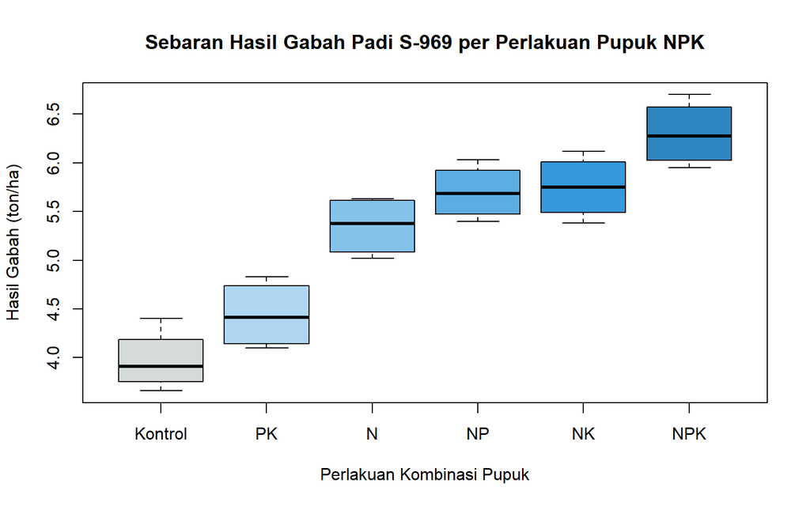

Figure 6.1: Boxplot eksplorasi sebaran hasil gabah Padi S-969 pada 6 perlakuan pupuk NPK.

```r
# Catatan tambahan jika suatu saat mengimpor dari Excel (.xlsx) atau teks (.txt):
# library(readxl)
# df_excel <- readxl::read_xlsx("../data/NamaFile.xlsx", sheet = 1)
# df_txt   <- read.delim("../data/NamaFile.txt", sep = "\t")

# Visualisasi eksplorasi awal dengan Boxplot
boxplot(Hasil_Gabah ~ Perlakuan, data = df_padi,
        col  = c("#d5dbdb", "#aed6f1", "#85c1e9", "#5dade2", "#3498db", "#2e86c1"),
        main = "Sebaran Hasil Gabah Padi S-969 per Perlakuan Pupuk NPK",
        xlab = "Perlakuan Kombinasi Pupuk",
        ylab = "Hasil Gabah (ton/ha)")
```

## 6.4 Cara Membaca Output R & Kesimpulan Eksplorasi

**Panduan Membaca Output `str()`, `summary()`, dan `boxplot()`:**

1. **Output `dim(df_padi)`**: Menghasilkan `[1] 24 3`, artinya terdapat **24 satuan pengamatan (petak sawah)** dan **3 peubah (kolom)**, sesuai dengan rancangan $6 \text{ perlakuan} \times 4 \text{ kelompok} = 24$ petak.
2. **Perubahan pada `str(df_padi)`**: Sebelum dikonversi, `Perlakuan` dan `Kelompok` tertulis sebagai `chr` (*character*). Setelah dikonversi dengan `factor()`, keduanya berubah menjadi `Factor w/ 6 levels` dan `Factor w/ 4 levels`, sedangkan `Hasil_Gabah` bertipe `num` (*numeric*). Ini menandakan dataset **100% siap dianalisis dengan `aov()`**.
3. **Output `summary(df_padi)`**:
   - Untuk peubah `factor` (`Perlakuan` dan `Kelompok`), R menampilkan **frekuensi/jumlah ulangan tiap taraf** (masing-masing perlakuan diulang 4 kali dan tiap kelompok memuat 6 perlakuan — data lengkap/seimbang!).
   - Untuk peubah `numeric` (`Hasil_Gabah`), R menampilkan nilai minimum (`3.660`), kuartil pertama (`4.588`), median (`5.475`), rata-rata umum (`5.252` ton/ha), kuartil ketiga (`5.912`), dan maksimum (`6.700` ton/ha).
4. **Kesimpulan Visual Boxplot**: Terlihat jelas adanya peningkatan hasil gabah secara konsisten dari perlakuan `Kontrol` (sekitar 4,0 ton/ha) menuju pemupukan lengkap `NPK` (melampaui 6,0 ton/ha), terutama ketika unsur Nitrogen (`N`) diberikan. Untuk membuktikan apakah perbedaan ini nyata secara statistik atau hanya kebetulan acak, kita akan mengujinya melalui **Analisis Ragam (ANOVA)** pada **Modul 01**!